# STAT 184 Final Project

Enying Gao

November 26, 2017

*Source file* ⇒ Final_Project.Rmd

### Data Description

The data come from a study on childhood obesity. Pregnant mothers were enlisted and then each child was followed from birth to two years old. The purpose of this analysis is to understand what role the human microbiome plays in childhood obesity. The human microbiome refers to the different bacteria that live inside/on humans. The following variables are available in the dataset.

- id: id of subject
- weight_born: weight at birth (in kg)
- height_born: height at birth (in cm)
- weight_2yr: weight at 2 years
- height_2yr: height at 2 years
- child_buccal_fb: Firmicutes-to-Bacteroidetes ratio in the child’s mouth. These are two phyla of bacteria. The ratio of their abundences are thought to play an important role in obesity.
- child_gut_fb: Firmicutes-to-Bacteroidetes ratio in the child’s gut.1
- mom_buccal_fb: Firmicutes-to-Bacteroidetes ratio in the mother’s mouth.
- child_buccal_alpha: Alpha diversity of types of bacteria in the child’s mouth. The alpha diversity is a summary of how diverse the types of bacteria are (i.e. are there lots of different types of bacteria).
- child_gut_alpha: Alpha diversity in the child’s gut.
- mom_buccal_alpha: Alpha diversity in the mother’s mouth.
- Treatment: There were two treatments as part of this study, with labels “Safety” and “Parenting”. “Safety” refers to the control group, while “Parenting” means the treatment group where the parents received nutritional training.
- Antibiotic: Did the child receive antibiotics in the first two years.
- Gender: Gender of the child.

### Load the data

```r
load("child_obese_data.Rdata")
head(child_obese)
```

```
##   id weight_born height_born weight_2yr height_2yr child_buccal_fb
## 1  1    3.712337    51.81976         NA         NA              NA
## 2  2    2.066262    51.28491   11.32099   88.50137       23.630935
## 3  3    4.118248    54.07935   12.52760   83.78521        1.782404
## 4  4    3.948013    51.03525         NA         NA              NA
## 5  5    4.022174    53.36464   11.05147   83.23308        1.848309
## 6  6    3.895072    52.35753   14.96314   88.48936        1.758953
##   child_gut_fb mom_buccal_fb child_buccal_alpha child_gut_alpha
## 1           NA            NA                 NA              NA
## 2    0.2649587     22.532844           2.048551        1.646911
## 3    0.4243042      7.034536           3.190728        2.025753
## 4           NA            NA                 NA              NA
## 5    7.6557240      6.264417           3.622135        1.457000
## 6    0.3407116      2.243395           3.878499        1.922044
##   mom_buccal_alpha Treatment Antibiotic Gender
## 1               NA      <NA>       <NA>   <NA>
## 2         2.693387 Parenting         No      M
## 3         1.857338    Safety         No      M
## 4               NA      <NA>       <NA>   <NA>
## 5         2.137427 Parenting         No      M
## 6         3.274502 Parenting         No      F
```

There are in total 279 observations and 14 variables in the dataset. However, some rows contain missing values and variable id is redundant. Therefore, we’d like to clean the data first.

### Drop NAs & ids

```r
child_obese<-na.omit(child_obese)
child_obese<-child_obese[,-1]
attach(child_obese)
str(child_obese)
```

```
## 'data.frame':    169 obs. of  13 variables:
##  $ weight_born       : num  2.07 4.12 4.02 3.9 2.97 ...
##  $ height_born       : num  51.3 54.1 53.4 52.4 47.7 ...
##  $ weight_2yr        : num  11.3 12.5 11.1 15 11.3 ...
##  $ height_2yr        : num  88.5 83.8 83.2 88.5 85.5 ...
##  $ child_buccal_fb   : num  23.63 1.78 1.85 1.76 0.68 ...
##  $ child_gut_fb      : num  0.265 0.424 7.656 0.341 74.134 ...
##  $ mom_buccal_fb     : num  22.53 7.03 6.26 2.24 9.16 ...
##  $ child_buccal_alpha: num  2.05 3.19 3.62 3.88 2.4 ...
##  $ child_gut_alpha   : num  1.65 2.03 1.46 1.92 1.27 ...
##  $ mom_buccal_alpha  : num  2.69 1.86 2.14 3.27 1.74 ...
##  $ Treatment         : Factor w/ 2 levels "Parenting","Safety": 1 2 1 1 2 2 2 1 2 1 ...
##  $ Antibiotic        : Factor w/ 2 levels "No","Yes": 1 1 1 1 1 1 1 1 1 2 ...
##  $ Gender            : Factor w/ 2 levels "F","M": 2 2 2 1 2 1 2 2 2 2 ...
```

```r
summary(child_obese)
```

```
##   weight_born     height_born      weight_2yr       height_2yr
##  Min.   :1.955   Min.   :44.72   Min.   : 9.175   Min.   :76.02
##  1st Qu.:3.013   1st Qu.:49.21   1st Qu.:11.500   1st Qu.:84.48
##  Median :3.484   Median :50.91   Median :12.400   Median :86.63
##  Mean   :3.480   Mean   :50.88   Mean   :12.517   Mean   :86.42
##  3rd Qu.:3.895   3rd Qu.:52.66   3rd Qu.:13.446   3rd Qu.:88.42
##  Max.   :4.885   Max.   :56.97   Max.   :17.704   Max.   :94.54
##  child_buccal_fb    child_gut_fb      mom_buccal_fb     child_buccal_alpha
##  Min.   :  0.251   Min.   :  0.1269   Min.   :  1.154   Min.   :1.159
##  1st Qu.:  2.191   1st Qu.:  0.4948   1st Qu.:  5.247   1st Qu.:1.982
##  Median :  3.221   Median :  0.8740   Median : 11.286   Median :2.445
##  Mean   :  6.581   Mean   :  8.2946   Mean   : 28.181   Mean   :2.489
##  3rd Qu.:  5.864   3rd Qu.:  1.7705   3rd Qu.: 30.329   3rd Qu.:2.915
##  Max.   :121.023   Max.   :655.8966   Max.   :371.221   Max.   :4.117
##  child_gut_alpha mom_buccal_alpha     Treatment  Antibiotic Gender
##  Min.   :1.182   Min.   :1.014    Parenting:87   No : 65    F:87
##  1st Qu.:2.047   1st Qu.:1.638    Safety   :82   Yes:104    M:82
##  Median :2.264   Median :2.049
##  Mean   :2.344   Mean   :2.169
##  3rd Qu.:2.610   3rd Qu.:2.681
##  Max.   :4.052   Max.   :4.386
```

Above is the summary of data we’re going to analyze on.

### Initial examination on weight

We’d first look at weight difference between gender at year 2 with factor Antibiotic.

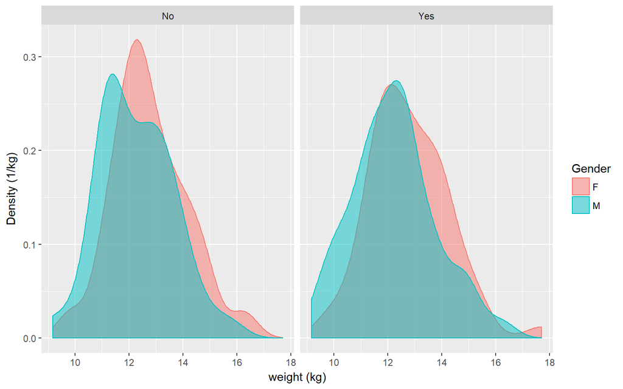

```r
child_obese %>%
  ggplot(aes(x=weight_2yr,group=Gender)) +
  geom_density(aes(color=Gender,fill=Gender),alpha=0.5) +
  xlab("weight (kg)") + ylab("Density (1/kg)") +
  facet_wrap(~Antibiotic)
```

We can see that in general female tends to be heavier than male and that Antibiotics doesn’t seem to play a huge role in impacting children’s weight.

Then we’d like to check the change between height and weight based on types of Treatment.

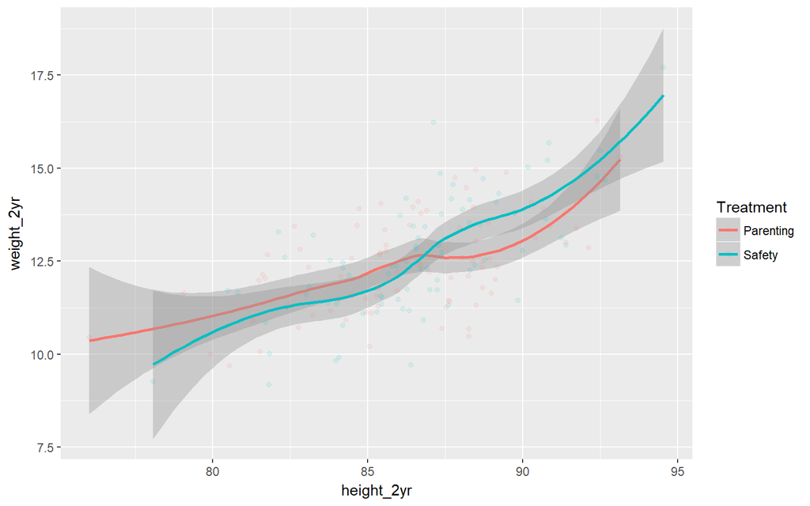

```r
child_obese %>%
  ggplot(aes(x=height_2yr, y=weight_2yr, color=Treatment)) +
  stat_smooth() +
  geom_point(alpha=0.1)
```

The confidence band for Parenting and Safety Treatment appears to be overlapped except in the range of 87cm - 92cm for height, which means that there’s a significant evidence suggesting that the children within this range differ in their weight. It can be inferred from the graph that children with Parenting Treatment tend to have lighter weight than those with Safety Treatment.

Next, we’d like to count the number of children who are considered as obese at year 2 by using BMI formula weight(kg)/height(m)^2

### Calculate BMI

```r
BMI_2yr<-weight_2yr/(height_2yr/100)^2
```

### Determine whether the child is overweight at year 2

```r
child_obese <-
  child_obese %>%
  mutate(overweight = factor(ifelse(BMI_2yr>18,"Yes","No")))
attach(child_obese)
head(child_obese,3)
```

```
##   weight_born height_born weight_2yr height_2yr child_buccal_fb
## 1    2.066262    51.28491   11.32099   88.50137       23.630935
## 2    4.118248    54.07935   12.52760   83.78521        1.782404
## 3    4.022174    53.36464   11.05147   83.23308        1.848309
##   child_gut_fb mom_buccal_fb child_buccal_alpha child_gut_alpha
## 1    0.2649587     22.532844           2.048551        1.646911
## 2    0.4243042      7.034536           3.190728        2.025753
## 3    7.6557240      6.264417           3.622135        1.457000
##   mom_buccal_alpha Treatment Antibiotic Gender overweight
## 1         2.693387 Parenting         No      M         No
## 2         1.857338    Safety         No      M         No
## 3         2.137427 Parenting         No      M         No
```

### Examination on overweight

We first check out the proportion of male and female that are considered as obese. We then use boxplot to determine the relationship between child_buccal_fb and overweight, since it is known that buccal_fb ratio plays an important role in obesity.

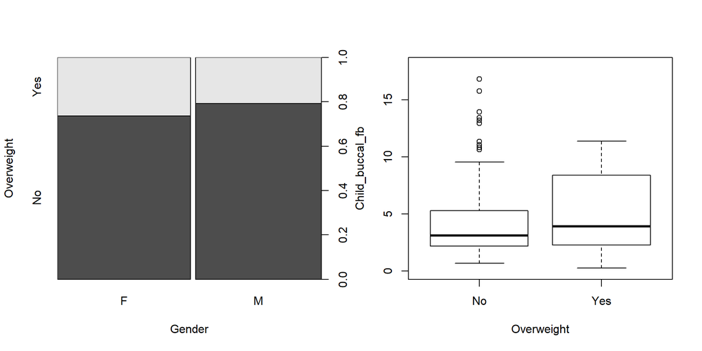

```r
par(mfrow=c(1,2))
plot(Gender,overweight,xlab='Gender',ylab='Overweight')
plot(overweight,child_buccal_fb,ylim=c(0,18),xlab='Overweight',ylab='Child_buccal_fb')
```

The stacked column chart shows that there are slightly more female considered to be overweight than male. The boxplot indicates that children who’re overweight tend to have higher buccal_fb ratio.

Next, we want to find out the impact of treatment on child obesity.

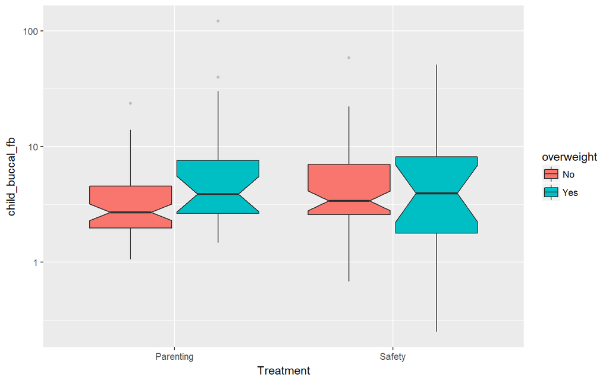

```r
child_obese %>%
  ggplot(aes(x=Treatment,y=child_buccal_fb)) +
  geom_boxplot(aes(fill=overweight), notch=TRUE, position=position_dodge(width=0.8), outlier.size=1, outlier.colour="gray") +
  scale_y_log10()
```

Then we want to determine if child_buccal_fb is related to other variables.

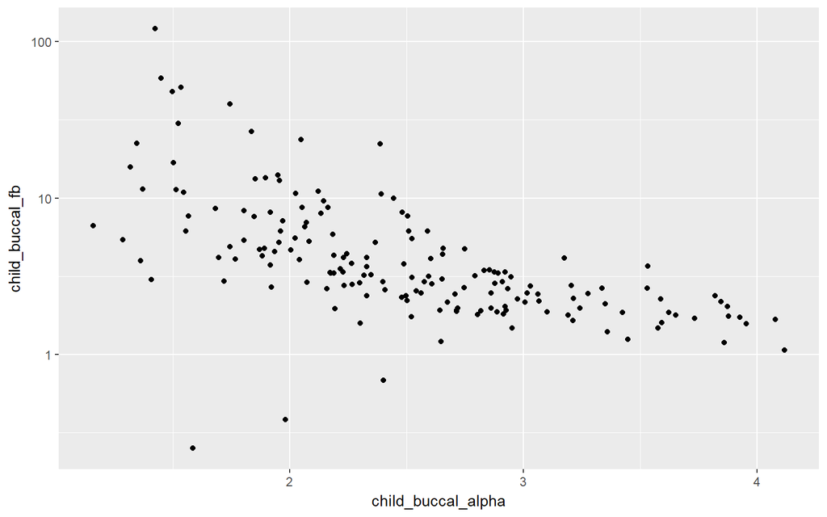

```r
child_obese %>%
  ggplot(aes(x=child_buccal_alpha,y=child_buccal_fb))+
  geom_point()+scale_y_log10()
```

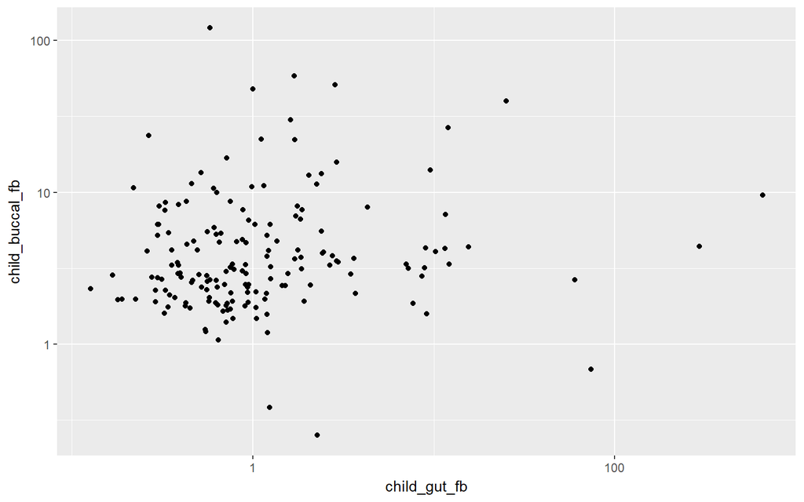

```r
child_obese %>%
  ggplot(aes(x=child_gut_fb,y=child_buccal_fb))+
  geom_point()+scale_x_log10()+scale_y_log10()
```

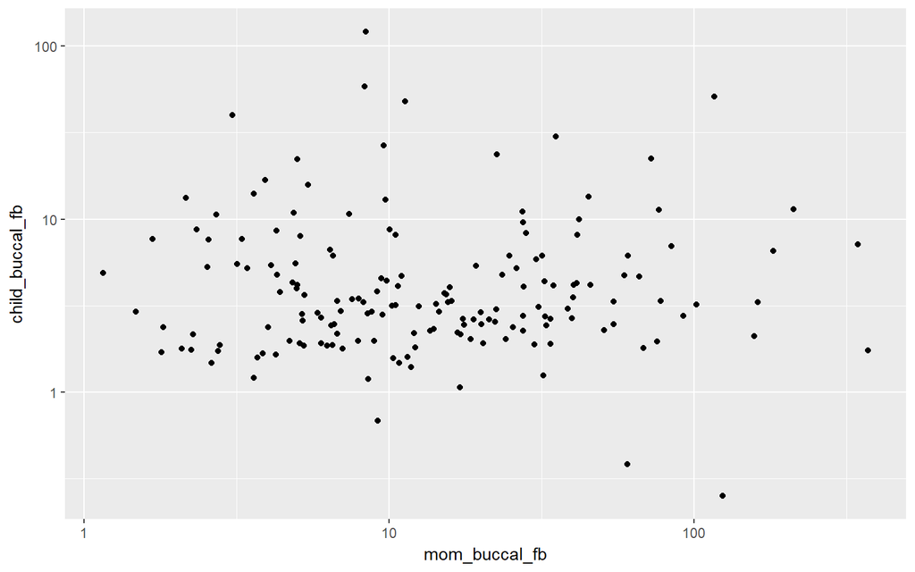

```r
child_obese %>%
  ggplot(aes(x=mom_buccal_fb,y=child_buccal_fb))+
  geom_point()+scale_x_log10()+scale_y_log10()
```

Finally, we want to have an overall picture of the individual variable’s impact on obesity.

[figure not shown]

```r
mod1 <- rpart(overweight ~ child_buccal_fb+child_buccal_alpha+child_gut_fb+child_gut_alpha+mom_buccal_fb+mom_buccal_alpha, data=child_obese)
fancyRpartPlot(mod1)
```

It can be inferred from the decision tree that aside from Treatment & Antibiotics, child_buccal_alpha, child_gut_alpha and child_buccal_fb are three most influential variables associated with obesity.

### Conclusion

Female tend to have higher weight than male. Obesity is associated with predictors child_buccal_fb, child_buccal_alpha and child_gut_alpha. As child_buccal_fb increases, child_buccal_alpha decreases, child_gut_alpha increases, and the chance of being overweight increases. According to this data, Antibiotics isn’t a major cause in obesity. Parenting can be useful in preventing obesity as children whose parents received nutritiaonal training seem to have lighter weight than those parents who did not.